# Quantiles

We begin by plotting examples from two classes of distributions: the log Normal and the student-t.

A random variable, $X$, is disributed as a log Normal with parameters $\mu$ and $\sigma$, if $\log(X) \sim N(\mu,\sigma)$. That is, the natural logarithm of $X$ is Normally distributed with mean $\mu$ and standard deviation $\sigma$. Note that the parameters $\mu$ and $\sigma$ represent the mean and standard deviation of $\log(X)$ and not $X$ itself. We can compute the density function of the log Normal for $\mu=0$ and $\sigma = \{1,0.5,0.2\}$ with the following code.

```r
mu = 0
sigVec = c(1,0.5,0.2)
support = seq(0,10,length=10000);
d1 = dlnorm(support, mu, sigVec[1]);
d2 = dlnorm(support, mu, sigVec[2]);
d3 = dlnorm(support, mu, sigVec[3]);
```

Let’s plot the densities:

```r
ymax = max(max(d1), max(d2), max(d3));
#par(bg="white")
plot(support, d1, ylim=c(0,ymax), type='l', ylab="", xlab="x",
     main=expression(paste("Lognormal Densities with ", mu, " = 0", sep="")));
lines(support, d2, lty=2);
```

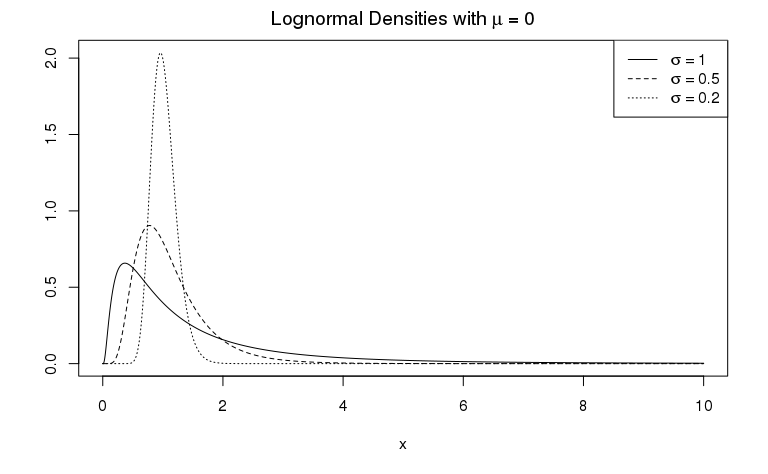

```r
lines(support, d3, lty=3);
legend("topright", legend=c(expression(paste(sigma, " = ", 1)),
       expression(paste(sigma, " = ", 0.5, sep="")),
       expression(paste(sigma, " = ", 0.2, sep=""))), lty=c(1,2,3))
```

The t distribution for degrees of freedom $df = \{4, 10, 30\}$ can be computed with the following code.

```r
dfVec = c(4,10,30)
support = seq(-3,3,length=10000)
d1 = dt(support, dfVec[1])
d2 = dt(support, dfVec[2])
d3 = dt(support, dfVec[3])
```

Let’s plot the densities:

```r
ymax = max(max(d1), max(d2), max(d3));
plot(support, d1, ylim=c(0,ymax), type='l', ylab="", xlab="x", main="t Densities");
lines(support, d2, lty=2);
```

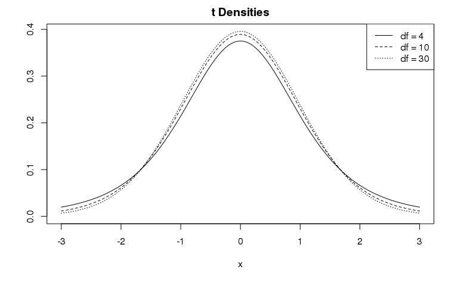

```r
lines(support, d3, lty=3);
legend("topright", legend=c("df = 4", "df = 10", "df = 30"), lty=c(1,2,3))
```

Next, we’ll create QQ-plots for several datasets. We’ll start by comparing the quantiles of S&P 500 returns against those of the Normal and those of several t distributions.

```r
library(Ecdat)
data(SP500)
r500 = SP500$r500
n = length(r500)
qGrid = (1:n)/(n+1)
par(mfrow=c(3,2), bg="white")
qqnorm(r500, datax=TRUE, xlab="Normal quantiles", ylab="Data",
       main="(a) Normal probability plot")
qqline(r500, datax=TRUE)
```

```r
qqplot(r500, qt(qGrid, df=1), xlab="Data", ylab="t quantiles",
       main="(b) t-prob plot, df=1")
qqline(r500, datax=TRUE, distribution=function(p){qt(p, df=1)})
```

```r
qqplot(r500, qt(qGrid, df=2), xlab="Data", ylab="t quantiles",
       main="(c) t-prob plot, df=2")
qqline(r500, datax=TRUE, distribution=function(p){qt(p, df=2)})
```

```r
qqplot(r500, qt(qGrid, df=4), xlab="Data", ylab="t quantiles",
       main="(d) t-prob plot, df=4")
qqline(r500, datax=TRUE, distribution=function(p){qt(p, df=4)})
```

```r
qqplot(r500, qt(qGrid, df=8), xlab="Data", ylab="t quantiles",
       main="(e) t-prob plot, df=8")
qqline(r500, datax=TRUE, distribution=function(p){qt(p, df=8)})
```

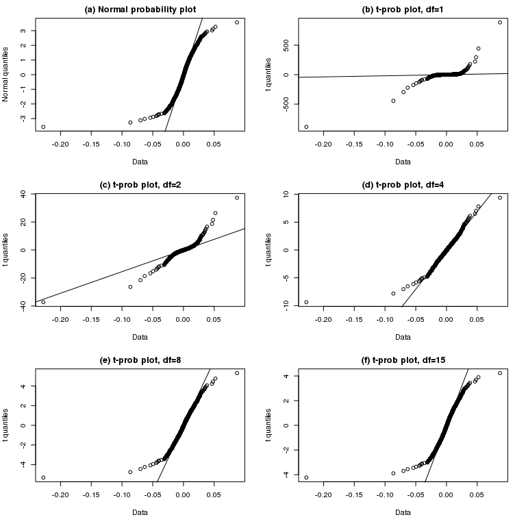

```r
qqplot(r500, qt(qGrid, df=15), xlab="Data", ylab="t quantiles",
       main="(f) t-prob plot, df=15")
qqline(r500, datax=TRUE, distribution=function(p){qt(p, df=15)})
```

Finally, we plot the quantiles of S&P 500 returns against quantiles of changes in the Duetchmark/US Dollar exchange rate and against the quantiles of the risk-free interest rate.

```r
data(Garch)
dm = Garch$dm
data(Capm)
rf = Capm$rf
par(mfrow=c(2,2), bg="white")
qqplot(r500, diff(dm), xlab="SP 500 Returns", ylab="Changes in DM", main="(a)")
abline(lm(quantile(diff(dm), c(0.25,0.75))~quantile(r500, c(0.25,0.75))))
```

```r
qqplot(r500, diff(rf), xlab="SP 500 Returns", ylab="Changes in Risk-free", main="(b)")
abline(lm(quantile(diff(rf), c(0.25,0.75))~quantile(r500, c(0.25,0.75))))
```

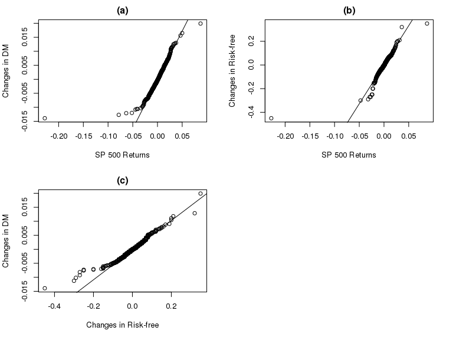

```r
qqplot(diff(rf), diff(dm), xlab="Changes in Risk-free", ylab="Changes in DM", main="(c)")
abline(lm(quantile(diff(dm), c(0.25,0.75))~quantile(diff(rf), c(0.25,0.75))))
```